# bcl_1629481158.htm

III.RESULTS AND ANALYSIS

[output not shown]

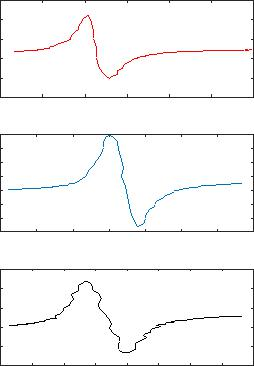

Conner Shoop

h

DPPH absorption in magnetic field with 9.170 GHz incident light; modulation amplitude 2

|  | 1000 |  |  |  |  |  |  |
| --- | --- | --- | --- | --- | --- | --- | --- |
| (mV) | 500 |  | Maximum =329.042 mT |  |  |  |  |
| signal | 0 |  |  |  |  |  |  |
| Reflected | -500 |  |  |  |  |  |  |
|  | -1000 |  |  | Minimum =329.2862 mT |  |  |  |
|  | -1500 |  |  |  |  |  |  |
|  | 328 | 328.5 | 329 | 329.5 | 330 | 330.5 | 331 |

Magnetic field (mT)

DPPH absorption in magnetic field with 9.170 GHz incident light; modulation amplitude 5

|  | 1000 |  |  |  |  |  |  |  |
| --- | --- | --- | --- | --- | --- | --- | --- | --- |
| (mV) | 500 |  |  |  |  |  |  |  |
|  | 0 |  |  |  |  |  |  |  |
| signal | -500 |  |  |  |  |  |  |  |
| Reflected | -1000 |  |  |  |  |  |  |  |
|  | -1500 |  |  |  |  |  |  |  |
|  | -2000 |  |  |  |  |  |  |  |
|  | -2500 |  |  |  |  |  |  |  |
|  | 327.5 | 328 | 328.5 | 329 | 329.5 | 330 | 330.5 | 331 |

Magnetic field (mT)

DPPH absorption in magnetic field with 9.170 GHz incident light; modulation amplitude 10

|  | 1000 |  |  |  |  |  |  |  |  |
| --- | --- | --- | --- | --- | --- | --- | --- | --- | --- |
| (mV) | 0 |  |  |  |  |  |  |  |  |
| signal | -1000 |  |  |  |  |  |  |  |  |
| Reflected | -2000 |  |  |  |  |  |  |  |  |
|  | -3000 |  |  |  |  |  |  |  |  |
|  | -4000 |  |  |  |  |  |  |  |  |
|  | 327.5 | 328 | 328.5 | 329 | 329.5 | 330 | 330.5 | 331 | 331.5 |

Magnetic field (mT)

FIG. 4. DPPH absorption spectrum in an increasing mag- netic eld with 9.170 GHz incident light. Modulated with dierent modulation amplitudes of 2, 5 and 10 (top to bot- tom). Maximum and minimum are labeled on the spectrum with modulation amplitude of 2.

In Figure 3 one can see another peak around 330 mT. This is the DPPH encased in resin. DPPH contains a better approximation to a free unpaired electron when measured with Electron Paramagnetic Resonance thus we will get a more approximate electroscopic splitting factor g. See the DPPH peak graphed with 2, 5, and 10mV modulation amplitudes in gure 4

3

A.Hyperne Interactions

When an electron occupies the ground state, the S or- bital, the wavefunction does not go to zero at the nucleus. This means in hydrogen, an s state electron interacts with the proton when near the nucleus. This interaction, also called Fermi contact [3], adds another term to the Hamil- tonian.

| H = gB  S + AI  S | (7) |
| --- | --- |

with I being the spin of the nucleus and A being the hy- perne parameter. We run a program called spinhalf on Matlab, which graphs eigenstates of hydrogen vs a mag- netic eld. The Hamiltonian is built up from the spin matrices of a proton and an electron and eigenstates of this Hamiltonian are calculated with an increasing mag- netic eld parallel to the z axis. We see the Hamiltonian is almost diagonal, H =

| 0.2398 | 0 | 0 | 0 |
| --- | --- | --- | --- |
| 0 | 0.2272 | 0.125 | 0 |
| 0 | 0.125 | -0.2398 | 0 |
| 0 | 0 | 0 | -0.2272 |

[3]

...suggesting the Hamiltonian would only depend on the eigenstate that is parallel to the magnetic eld, ie: the eigenstate along the z axis (Sz). An easier way to picture it is that the x and y components of the hyper- ne interaction are nearly perpendicular to the magnetic eld, thus they do not aect the Hamiltonian much other than at low magnetic eld strengths. One can see their increased importance to determine an eigenstate at low magnetic eld values in gure 5

Thus we can rewrite (7) only taking into account the Z component of spin,

| H = gBzSz + AIzSz | (8) |
| --- | --- |

Equation (9) is interesting because it shows existence of 4 eigenstates in a Hydrogen atom with a xed mag- netic eld and this suggests 6 dierent energy transitions. However, there are only two allowed transitions because the nucleus will not switch spin, thus the only transitions are je+; p > to je; p > and je+; p+ > to je; p+ > We can plug in spin values for the electron and proton and nd the dierence in energies for g=2

| jH++  H+j = jH+  Hj | (9) |
| --- | --- |

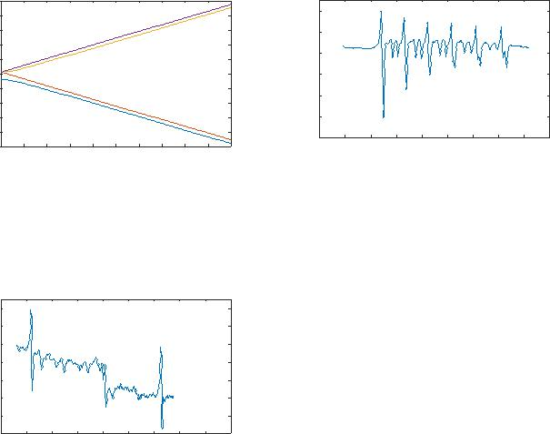

Conner Shoop

h

Energy Eigenvalues versus Magnetic Field Strength

|  | 0.25 |  |  |  |  |  |  |  |  |  |  |
| --- | --- | --- | --- | --- | --- | --- | --- | --- | --- | --- | --- |
|  | 0.2 |  |  |  |  |  |  |  |  |  |  |
|  | 0.15 |  |  |  |  |  |  |  |  |  |  |
| ) |  |  |  |  |  |  |  |  |  |  |  |
| -1 | 0.1 |  |  |  |  |  |  |  |  |  |  |
| (cm |  |  |  |  |  |  |  |  |  |  |  |
| Eigenvalues | 0.05 |  |  |  |  |  |  |  |  |  |  |
|  | 0 |  |  |  |  |  |  |  |  |  |  |
|  | -0.05 |  |  |  |  |  |  |  |  |  |  |
| Energy |  |  |  |  |  |  |  |  |  |  |  |
|  | -0.1 |  |  |  |  |  |  |  |  |  |  |
|  | -0.15 |  |  |  |  |  |  |  |  |  |  |
|  | -0.2 |  |  |  |  |  |  |  |  |  |  |
|  | -0.25 |  |  |  |  |  |  |  |  |  |  |
|  | 0 | 50 | 100 | 150 | 200 | 250 | 300 | 350 | 400 | 450 | 500 |

Magnetic Field Strength (mT)

FIG. 5. The energy eigenvalues of a Hydrogen atom in a homogeneous magnetic eld vs increasing magnetic eld strength. The x and y components of spin aect the linearity of the eigenvalues near T=0, but they are negligible above 0.1T.

h

Irradiated Beryl absorption in a magnetic field with 9.167 GHz incident light

|  | -80 |  | Maximum =301.6546 mT |  |  |  |  |  |  |  |
| --- | --- | --- | --- | --- | --- | --- | --- | --- | --- | --- |
|  | -100 |  |  |  |  |  |  |  |  |  |
| (mV) | -120 |  |  |  |  |  |  | Maximum =352.4434 mT |  |  |
| signal | -140 |  |  |  |  |  |  |  |  |  |
| Reflected | -160 |  |  |  |  |  |  |  |  |  |
|  |  |  | Minimum =302.2352 mT |  |  |  |  |  |  |  |
|  | -180 |  |  |  |  |  |  |  |  |  |
|  | -200 |  |  |  |  |  |  |  |  |  |
|  |  |  |  |  |  |  |  | Minimum =352.9939 mT |  |  |
|  | -220 |  |  |  |  |  |  |  |  |  |
|  | 290 | 300 | 310 | 320 | 330 | 340 | 350 | 360 | 370 | 380 |

Magnetic field (mV)

FIG. 6. Irradiated Beryl absorption in a magnetic eld with 9.167 GHz incident light. Two major transitions are observed near 300mT and 350mT, the maximums and minimums are provided.

| jB+  Bj = B = | A~ | (10) |
| --- | --- | --- |
|  | g |  |

So now we are condent that we will see two transition with a free hydrogen atom. A material called irradiated Beryl is the perfect candidate to search for these two transitions. With irradiated Beryl in the sample chamber we sweep the magnetic eld while showering Beryl with 9.167 GHz light. Our spectrum is shown in gure 6.

327.21mT. Using equation (3) at this point we nd

g = 2:004  0:011, a very accurate approximation. Using

4

h

Greentack absorbance in magnetic field with 8.945 GHz incident light

|  | 200 |  |  |  |  |  |  |  |  |  |
| --- | --- | --- | --- | --- | --- | --- | --- | --- | --- | --- |
|  | 100 |  |  |  |  |  |  |  |  |  |
| (mV) | 0 |  |  |  |  |  |  |  |  |  |
| signal |  |  |  |  |  |  |  |  |  |  |
| Reflected | -100 |  |  |  |  |  |  |  |  |  |
|  | -200 |  |  |  |  |  |  |  |  |  |
|  | -300 |  |  |  |  |  |  |  |  |  |
|  | -400 |  |  |  |  |  |  |  |  |  |
|  | 280 | 290 | 300 | 310 | 320 | 330 | 340 | 350 | 360 | 370 |

Magnetic field (mT)

FIG. 7. Greentack absorption in a magnetic eld with 8.94 GHz incident light. One can see 6 absorption peaks and that they decrease with larger magnetic eld values

The number of energy transitions corresponding to electron spin ips is equal to 2I + 1 with I the nuclear spin.[3] In the absorption spectrum for greentack, there are clearly 6 peaks which lead to I = 52 . Oxygen-17 has a nuclear spin of 52 [6]. I think this is the most likely ion producing this graph, since greentack would be exposed to it any time it comes in contact with water which may be frequent during the manufacturing or processing pro- cesses. Some down-steps in absorbance can be observed in greentack's absorbance spectrum, and they seem to be consistent, two in between every large peak. I believe this is the result of nuclear spin interacting with the mag- netic eld. As the magnetic eld increases, the absorp- tion peaks become smaller because nuclear spin values are lower, accounting for less change in the Hamiltonian. These steps down could be re-orientations of the nuclear spin polarization that are brought on by increasing the magnetic eld. They also suggest the existance of an- other contaminate with a much higher nuclear spin than Oxygen-17.

IV. CONCLUSION

The electron paramagnetic resonance lab was one of the most intricate and theoretically dense labs I have ever

Conner Shoop

5

V.REFERENCES

[1]S. A. Wolf, Science Spintronics: A Spin-Based Elec- tronics Vision for the Future, 1488-1495, 2001.

[2]Griths, David J. (2007) Introduction to Electrody- namics, 3rd Edition, World Publishing Company, 1998.

[3]Uli Zuelicke, Phys 307 Electron Spin Resonance Lab Manual, 2017.

[4]J. Alexander. Basic Rules for Uncertainty Calcula- tions [Online].

http://web.uvic.ca/ jalexndr/192UncertRules.pdf

[5]Griths, David Jerey. Introduction to Quantum Mechanics. Cambridge: Cambridge UP, 2017.

[6]Blinder, Seyour. Nuclear Magnetic Resonance [On-

line].

https://chem.libretexts.org/Core/Physical and Theoretical Chem Mechanics/Chapter 14. Nuclear Magnetic Resonance

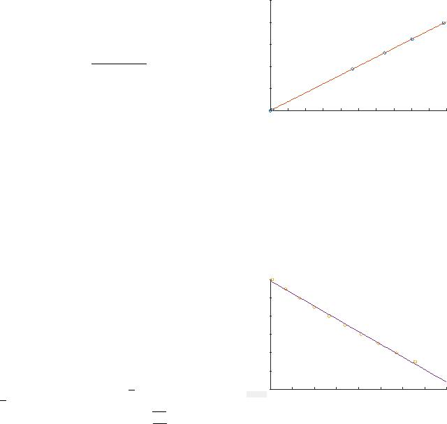

Conner Shoop

Appendix A: Helmholtz Coil [2]

Magnetic eld of current I in loop of radius R at a distance z above the center of the loop along its axis.

u0IR2

B =(A1) 2(R2 + z2)1=2

Now two coils a distance d apart along the center axis with z=0 as the midpoint between them.

[output not shown]

(A2) The rst derivative of this equation with respect to z will always be zero when setting z=0. However, by taking the second derivative and setting this to zero at z=0, one

gets

| d = R | (A3) |
| --- | --- |

The criteria for a Helmholtz coil is now found. A Helmholtz coil creates a very good approximation to a homogeneous magnetic eld near the center of the two coils.

Appendix B: Maxwell-Boltzmann distribution

Evidence of the Maxwell-Boltzmann distribution can be shown with statistics. Consider a system of n har- monic oscillators that can contain energy in the form of quanta. Now give the system m quanta with m<n. If a condition is made that all of the oscillators have no more than one quanta each, there are (mn ) states of the system,

(mn ) being the choose function. If a new condition says all oscillators has 2 quanta, there are (m=n 2 ) states of the system. Three quanta per oscillator, (m=n 3 ). If one con-

tinues this they can see that as the condition changes and oscillators occupy higher energy states, the total number of states of the system decreases. Since the number of states of a system is proportional to the probability of a system with that condition existing, one can see that the oscillators are more likely to occupy a lower energy state.

An exact derivation using the partition function can be found from the Grand Canonical Ensemble.

Appendix C: mV to mT relation

While sweeping the magnetic eld, readings of the magnetic eld in mT were recorded along with the data logged in mV

6

Magnetic Field signal in mV relation to Tesla

|  | 250 |  |  |  |  |  |  |  |  |  |  |
| --- | --- | --- | --- | --- | --- | --- | --- | --- | --- | --- | --- |
|  |  |  | y = 0.2002x |  |  |  |  |  |  |  |  |
|  |  |  | +0.2335 |  |  |  |  |  |  |  |  |
|  | 200 |  |  |  |  |  |  |  |  |  |  |
| (mT) | 150 |  |  |  |  |  |  |  |  |  |  |
| field |  |  |  |  |  |  |  |  |  |  |  |
| Recorded | 100 |  |  |  |  |  |  |  |  |  |  |
|  | 50 |  |  |  |  |  |  |  |  |  |  |
|  | 0 |  |  |  |  |  |  |  |  |  |  |
|  | 0 | 100 | 200 | 300 | 400 | 500 | 600 | 700 | 800 | 900 | 1000 |

Signal (mV)

Logged data value of eld in mV versus manually recorded Tesla reading, plotted and linearly t to nd an accurate relation equation.

field(mT ) = 0:2002  signal(mV ) + 0:2335  0:001 for all recorded data in this lab.

Appendix D: Wavemeter Calibration

We were given a list of data to calibrate our wavemeter in the back of our lab manual. [3]

WAVEMETER CALIBRATION

|  | 10 |  |  |  |  |  |  |  |  |  |
| --- | --- | --- | --- | --- | --- | --- | --- | --- | --- | --- |
|  | 9.8 |  |  |  |  | Y = 11.9321 - 0.2779X |  |  |  |  |
|  | 9.6 |  |  |  |  |  |  |  |  |  |
| Z |  |  |  |  |  |  |  |  |  |  |
| GH | 9.4 |  |  |  |  |  |  |  |  |  |
|  | 9.2 |  |  |  |  |  |  |  |  |  |
|  | 9 |  |  |  |  |  |  |  |  |  |
|  | 8.8 |  |  |  |  |  |  |  |  |  |
| Y = 11.9321 |  | 7 | 7.5 | 8 | 8.5 | 9 | 9.5 | 10 | 10.5 | 11 |
| - 0.2779X |  |  |  |  |  | MM |  |  |  |  |

Ghz of light from Gunn Diode versus manually recorded wavemeter mm measurements, linearly t to nd an accurate relation equation.

We now have a relation between mm on the wavemeter and the frequency of our light. freq(GHz) = 11:931  0:2779  length(mm)  0:01

1A Helmholtz coil, invented by Herman von Helmholtz of course, is a setup of coils used to create a homogeneous magnetic eld. See appendix A.

2The Maxwell-Boltzmann distribution is a distribution of particles' probability density vs particle energy of particles in an isolated

system of multiple particle states. It shows that particles are most likely to occupy a low energy state. See appendix B.

3Time independent permutation theory states that the magnetic eld of the photon must be aligned parallel to the magnetic eld

for absorption to occur[5].

4We have these specic frequencies because they are not a multiple of the national electricity frequency in New Zealand of 50Hz.